# Mint Classics - Analyze Data in a Model Car Database with MySQL Workbench

Parthebhan Pari

2023-12-28

# ASK

[output not shown]

# Project Objectives

1. Explore products currently in inventory.
2. Determine important factors that may influence inventory reorganization/reduction.
3. Provide analytic insights and data-driven recommendations.

# Business Talk with Mint Classic’s Stake Holders

1. Are there products with high inventory but low sales? How can we optimize the inventory of such products?
2. Are all the warehouses currently in use still necessary? How can we review warehouses that have low or inactive inventory?
3. Is there a relationship between product prices and their sales levels? How can price adjustments impact sales?
4. Who are the customers contributing the most to sales? How can sales efforts be focused on these valuable customers?
5. How can the performance of sales employees be evaluated using sales data?
6. How can customer payment trends be analysed? .
7. How can the performance of various product lines be compared? Which products are the most successful, and which ones need improvement or removal?

8.How can the company’s credit policies be evaluated? Are there any customers with credit issues that need to be addressed?

# Task 1 – Import the Classic Model Car Relational Database

Downloaded “mintclassicsDB.sql” to create and populate Mint Classics relational database in MySQL.

R Markdown is employed for report creation, allowing seamless integration of code, text, and output in a single document.

## Connect to MySQL database using ODBC in R

```r
# Loading essential libraries for analysis:

library(RODBC)
library(DBI)
library(odbc)

# Establish a connection to MySQL database using the "MySQL_DSN" data source name

con <- dbConnect(odbc::odbc(),"MySQL_DSN")
```

# Task 2 – Familiarize with the Mint Classic database and business processes.

In the Mint Classics Company’s database, there are 9 tables, each serving a specific purpose:

1. Warehouses: Compiles data on the company’s warehouses used for storing product inventory.
2. Products: Compiles data about product types, stock quantities, sales quantities, purchase prices, and more.

3.Product Lines:Compiles data about the descriptions of each product line the company sells.

4.Customers: Compiles data about customer profiles, including names, addresses, credit limits, and other details.

5. Payments: Compiles data about payments made by customers, including payment dates and amounts.
6. Orders: Compiles data regarding customer orders for specific products.
7. Order Details: Compiles data about orders for specific products, including the quantity of products ordered and the price of each product.
8. Employees: Compiles data about company employees, including names, addresses, offices, and more.
9. Offices: Compiles data about company office profiles.

These tables collectively store information essential for managing inventory, tracking sales, handling customer orders, processing payments, managing employees, and organizing the company’s physical infrastructure.

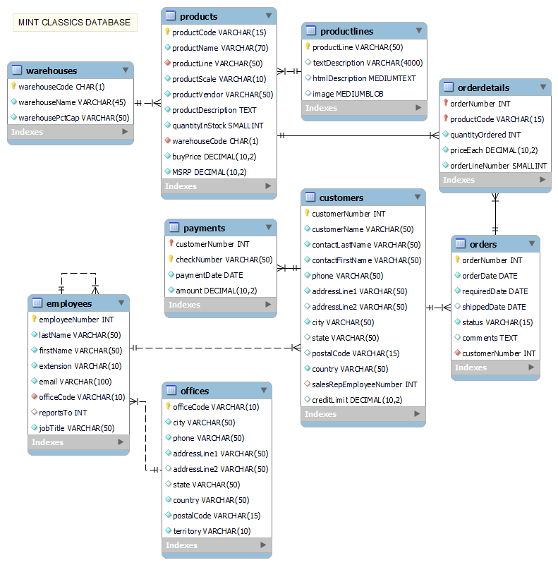

# Task 3 – Investigate the business problem and identifing tables impacted.

# Question 1 : Are there products with high inventory but low sales? How can we optimize the inventory of such products?

```sql
-- To Get the products with high inventory but low sales

Select productName,
       quantityInStock,
       sum(quantityOrdered),
       (quantityInStock-sum(quantityOrdered)) as Current_Inventory,
       (sum(quantityOrdered) / avg(quantityInStock)) as Inventory_Turnover_Ratio
from products as p
left join orderdetails as o
  on p.productCode = o . productCode
  group by productName,quantityInStock
  order by Inventory_Turnover_Ratio
  limit 20
```

```r
# The products with high inventory but low sales

print(Question_1)
```

```
##                                 productName quantityInStock
## 1                         1985 Toyota Supra            7733
## 2                          1995 Honda Civic            9772
## 3                       2002 Chevy Corvette            9446
## 4                         1982 Ducati 996 R            9241
## 5                     1976 Ford Gran Torino            9127
## 6                     1965 Aston Martin DB5            9042
## 7                        1968 Dodge Charger            9123
## 8            America West Airlines B757-200            9653
## 9                 1932 Model A Ford J-Coupe            9354
## 10                         2002 Suzuki XREO            9997
## 11             1999 Indy 500 Monte Carlo SS            8164
## 12           1948 Porsche Type 356 Roadster            8990
## 13         1912 Ford Model T Delivery Wagon            9173
## 14   1950's Chicago Surface Lines Streetcar            8601
```

[output cut: 27 more lines]

## Observations in the analysis:

## Products like “1985 Toyota Supra” have high inventory and low sales. Optimization includes targeted promotions, adjusting pricing, and improving demand forecasting to reduce excess stock and enhance overall inventory turnover.

# Question 2: Are all the warehouses currently in use still necessary? How can we review warehouses that have low or inactive inventory?

```sql
-- Total Available stock WRT Product Line

Select w.warehouseName,
       p.productLine,
       sum(p.quantityInStock) as Available_Stock
from products as p
inner join warehouses as w
   on p.warehouseCode = w.warehouseCode
   group by w.warehouseName,p.productLine
   order by Available_Stock desc
```

```r
# Total Available stock WRT Product Line
print(Question_2a)
```

```
##   warehouseName      productLine Available_Stock
## 1          East     Classic Cars          219183
## 2          West     Vintage Cars          124880
## 3         North      Motorcycles           69401
## 4         North           Planes           62287
## 5         South Trucks and Buses           35851
## 6         South            Ships           26833
## 7         South           Trains           16696
```

```sql
-- Total Available stock WRT warehouse name

Select w.warehouseName,
       sum(p.quantityInStock) as Available_Stock
from products as p
inner join warehouses as w
    on p.warehouseCode = w.warehouseCode
    group by w.warehouseName
    order by Available_Stock desc
```

```r
# Total Available stock WRT warehouse name

print(Question_2b)
```

```
##   warehouseName Available_Stock
## 1          East          219183
## 2         North          131688
## 3          West          124880
## 4         South           79380
```

## Observations in the analysis:

## Based on the analysis of available stock across warehouses, it appears that all warehouses are still necessary. Each warehouse holds substantial stock for different product lines, indicating ongoing operational relevance. Consider optimizing inventory distribution but retaining all warehouses to ensure timely service and accommodate varying product demands across regions.

# Question 3: Is there a relationship between product prices and their sales levels? How can price adjustments impact sales?

```sql
 -- To Find Correlation between Buy price and Quantity_Ordered

 Select p.productCode,
        p.productName,
        p.buyPrice,sum(od.quantityOrdered) as Quantity_Ordered
 from products as p
 left join orderdetails as od
    on p.productCode = od.productCode
    Group by p.productCode,productName
    order by buyPrice desc
    Limit 20
```

```r
print(Question_3)
```

```
##    productCode                          productName buyPrice Quantity_Ordered
## 1     S10_4962               1962 LanciaA Delta 16V   103.42              932
## 2     S18_2238       1998 Chrysler Plymouth Prowler   101.51              986
## 3     S10_1949             1952 Alpine Renault 1300    98.58              961
## 4     S24_3856              1956 Porsche 356A Coupe    98.30             1052
## 5     S12_1108                    2001 Ferrari Enzo    95.59             1019
## 6     S12_1099                    1968 Ford Mustang    95.34              933
## 7     S18_1984                     1995 Honda Civic    93.89              917
## 8     S18_4027                1970 Triumph Spitfire    91.92              945
## 9     S10_4698 2003 Harley-Davidson Eagle Drag Bike    91.02              985
## 10    S12_3148                   1969 Corvair Monza    89.14              963
## 11    S18_1749             1917 Grand Touring Sedan    86.70              918
## 12    S10_4757                  1972 Alfa Romeo GTA    85.68             1030
## 13    S18_4600                     1940s Ford truck    84.76             1061
## 14    S18_1129                      1993 Mazda RX-7    83.51              947
## 15    S12_3891                     1969 Ford Falcon    83.05              965
## 16    S24_2011                18th century schooner    82.34             1011
## 17    S12_1666                       1958 Setra Bus    77.90              972
## 18    S18_3232          1992 Ferrari 360 Spider red    77.90             1808
## 19    S18_1662          1980s Black Hawk Helicopter    77.27             1040
## 20    S12_3380                   1968 Dodge Charger    75.16              925
```

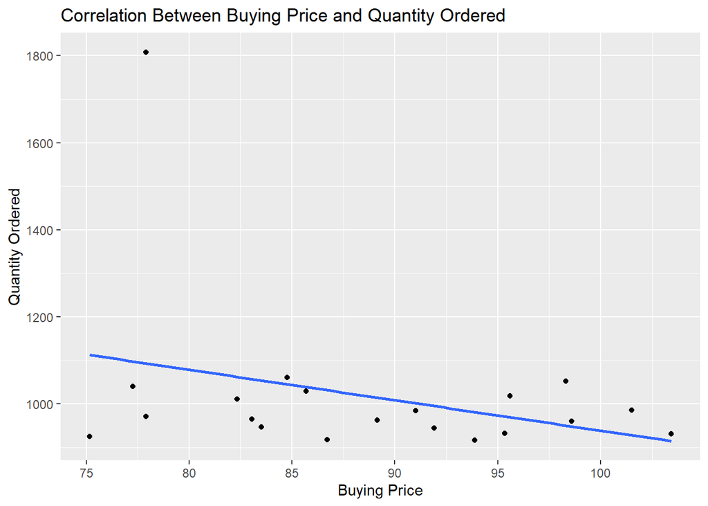

```r
# Correlation between Buy price and Quantity_Ordered

# Load ggplot2

library(ggplot2)

# Create a scatter plot
ggplot(Question_3, aes(x = buyPrice, y = Quantity_Ordered)) +
  geom_point() +
  geom_smooth(method = "lm", se = FALSE) +
  labs(title = "Correlation Between Buying Price and Quantity Ordered",
       x = "Buying Price",
       y = "Quantity Ordered")
```

## Observations in the analysis:

# Question 4: Who are the customers contributing the most to sales? How can sales efforts be focused on these valuable customers?

```sql
 -- Customers contributing the most to sales

 Select p.customerNumber as Customer_Number,
        c.customerName as Customer_Name,
        round(sum(amount),0) as Total_Sales_Amount
  from payments as p
  inner join customers as c
        on  p.customerNumber=c.customerNumber
        group by p.customerNumber
        Order by Total_Sales_Amount desc
        Limit 15
```

```r
print(Question_4)
```

```
##    Customer_Number                Customer_Name Total_Sales_Amount
## 1              141       Euro+ Shopping Channel             715739
## 2              124 Mini Gifts Distributors Ltd.             584188
## 3              114   Australian Collectors, Co.             180585
## 4              151           Muscle Machine Inc             177914
## 5              148      Dragon Souveniers, Ltd.             156251
## 6              323   Down Under Souveniers, Inc             154622
## 7              187               AV Stores, Co.             148410
## 8              276      Anna's Decorations, Ltd             137034
## 9              321     Corporate Gift Ideas Co.             132341
## 10             146       Saveley & Henriot, Co.             130305
## 11             278                Rovelli Gifts             127530
## 12             353           Reims Collectables             126983
## 13             119            La Rochelle Gifts             116950
## 14             363 Online Diecast Creations Co.             116449
## 15             496            Kelly's Gift Shop             114497
```

## Observations in the analysis:

## The top contributing customers to sales are Euro+ Shopping Channel and Mini Gifts Distributors Ltd. To focus sales efforts on these valuable customers, implement personalized marketing strategies, offer exclusive promotions, and ensure excellent customer service. Analyze their preferences to tailor product recommendations, fostering long-term relationships and maximizing revenue.

# Question 5: How can the performance of sales employees be evaluated using sales data?

```sql
-- Performance of Sales Employees

select  e.employeeNumber as Employee_Number,
        concat(e.firstName," ",e.lastName) as Employee_Name,
        sum(od.priceEach * od.quantityOrdered) as Total_Sales_Amount
from employees as e
   left join customers as c
     on e.employeeNumber = c.salesRepEmployeeNumber
   left join orders as o
     on c.customerNumber = o.customerNumber
   left join orderdetails as od
       on o.orderNumber = od.orderNumber
     group by e.employeeNumber,e.lastName,e.firstName
     order by Total_Sales_Amount desc
     limit 15
```

```r
# Performance of Sales Employees

print(Question_5)
```

```
##    Employee_Number    Employee_Name Total_Sales_Amount
## 1             1370 Gerard Hernandez          1258577.8
## 2             1165  Leslie Jennings          1081530.5
## 3             1401  Pamela Castillo           868220.6
## 4             1501       Larry Bott           732096.8
## 5             1504      Barry Jones           704853.9
## 6             1323    George Vanauf           669377.1
## 7             1612      Peter Marsh           584593.8
## 8             1337      Loui Bondur           569485.8
## 9             1611      Andy Fixter           562582.6
## 10            1216  Steve Patterson           505875.4
## 11            1286   Foon Yue Tseng           488212.7
## 12            1621       Mami Nishi           457110.1
## 13            1702    Martin Gerard           387477.5
## 14            1188   Julie Firrelli           386663.2
## 15            1166  Leslie Thompson           347533.0
```

## Observations in the analysis:

## Gerard Hernandez leads in total sales among employees, demonstrating strong sales performance. To enhance overall sales, consider leveraging Hernandez’s strategies and providing targeted training. Recognize and reward top performers, fostering a competitive yet collaborative sales environment that motivates the team to achieve higher revenue goals.

# Question 6: How can customer payment trends be analysed?

```sql
-- Customer Payment Trends

 Select c.customerName as Customer_Name,
            c.customerNumber as Customer_Number,
            orderDate as Order_Date,
            paymentDate as Payment_Date,
            datediff(paymentDate,orderDate) as Date_Difference,
            amount as Payment_Amount
 from payments as p
 inner join orders as o
   on  p.customerNumber = o.customerNumber
 inner join customers as c
   on c.customerNumber = p.customerNumber
   order by date_difference desc
   limit 30
```

```r
# Customer Payment Trends

print(Question_6)
```

```
##                   Customer_Name Customer_Number Order_Date Payment_Date
## 1        Euro+ Shopping Channel             141 2003-01-31   2005-05-19
## 2        Euro+ Shopping Channel             141 2003-01-31   2005-03-25
## 3        Euro+ Shopping Channel             141 2003-01-31   2005-03-18
## 4            Reims Collectables             353 2003-05-07   2005-06-09
## 5  Mini Gifts Distributors Ltd.             124 2003-03-26   2005-04-16
## 6        Euro+ Shopping Channel             141 2003-06-06   2005-05-19
## 7       Dragon Souveniers, Ltd.             148 2003-04-16   2005-03-27
## 8  Mini Gifts Distributors Ltd.             124 2003-03-26   2005-03-05
## 9            Reims Collectables             353 2003-07-10   2005-06-09
## 10                 Alpha Cognac             242 2003-07-04   2005-06-03
## 11       Euro+ Shopping Channel             141 2003-01-31   2004-12-31
## 12   Down Under Souveniers, Inc             323 2003-06-25   2005-05-23
## 13       Euro+ Shopping Channel             141 2003-06-27   2005-05-19
## 14            Kelly's Gift Shop             496 2003-07-07   2005-05-25
```

[output cut: 47 more lines]

## Observations in the analysis:

## The analysis reveals notable payment trends among customers. Euro+ Shopping Channel consistently exhibits extended date differences, potentially impacting cash flow. Mini Gifts Distributors Ltd. and Reims Collectables also demonstrate significant variations. Strategies for prompt communication, targeted promotions, and credit term adjustments may be considered to optimize payment cycles and enhance financial stability.

# Question 7: How can the performance of various product lines be compared? Which products are the most successful, and which ones need improvement or removal?

```sql
-- Performance of various product lines

Select p.productLine,
       sum(quantityInStock) as Total_Inventory,
       sum(quantityOrdered) as Total_sales,
       sum(quantityOrdered*priceEach) as Total_Revenue,
       (sum(quantityOrdered)/sum(quantityInStock))*100 as Sales_to_Inventory_Percentage
 from products as p
 left join productlines as pl
    on p.productLine = pl.productLine
 left join orderdetails as od
    on p.productCode = od.productCode
    group by p.productLine
    order by Total_Revenue desc
```

```r
# Performance of various product lines

print(Question_7)
```

```
##        productLine Total_Inventory Total_sales Total_Revenue
## 1     Classic Cars         5851766       35582     3853922.5
## 2     Vintage Cars         3439570       22933     1797559.6
## 3      Motorcycles         1915517       12778     1121426.1
## 4 Trucks and Buses         1003828       11001     1024113.6
## 5           Planes         1744036       11872      954637.5
## 6            Ships          732251        8532      663998.3
## 7           Trains          450792        2818      188532.9
##   Sales_to_Inventory_Percentage
## 1                        0.6081
## 2                        0.6667
## 3                        0.6671
## 4                        1.0959
## 5                        0.6807
## 6                        1.1652
## 7                        0.6251
```

## Observations in the analysis:

# Question 8: How can the company’s credit policies be evaluated? Are there any customers with credit issues that need to be addressed?

```sql
 -- Company’s credit policies evaluation

 Select c.customerName as Customer_Name,
            c.customerNumber as Customer_Number,
            sum(c.creditLimit) as Credit_Limit,
        sum(p.amount) as Total_payment,
        (sum(p.amount)-sum(c.creditLimit)) as Credit_Limit_Diff
 from payments as p
 left join customers as c
   on p.customerNumber = c.customerNumber
   Group by c.customerNumber,c.creditLimit
   Having
   sum(p.amount) < sum(c.creditLimit)
   order by Total_payment
   Limit 15
```

```r
# Company’s credit policies evaluation

print(Question_8)
```

```
##                         Customer_Name Customer_Number Credit_Limit
## 1                   Boards & Toys Co.             219        22000
## 2             Auto-Moto Classics Inc.             198        69000
## 3                   Atelier graphique             103        63000
## 4                  Frau da Collezione             473        69600
## 5                        Royale Belge             381        94000
## 6                     Microscale Inc.             456        79600
## 7      Double Decker Gift Stores, Ltd             489        86600
## 8  Bavarian Collectables Imports, Co.             415        77000
## 9          Cambridge Collectables Co.             173        86800
## 10                  Gifts4AllAges.com             362        83800
## 11            Tekni Collectables Inc.             328        86000
## 12         Men 'R' US Retailers, Ltd.             347       115400
## 13           Signal Collectibles Ltd.             487       120600
## 14           Volvo Model Replicas, Co             144       106200
```

[output cut: 17 more lines]

### Observations in the analysis:

# Task 4 – Suggestions and Recommendations for solving the business problem.

# SHARE AND ACT

### Credit Policy Review: Address credit limit discrepancies for customers like “Boards & Toys Co.” and “Auto-Moto Classics Inc.” by promptly reassessing and adjusting credit policies.

# CONCLUSION

```r
# Disconnect using odbc

dbDisconnect(con)

# Gratitude to Google and Coursera for invaluable learning opportunities.
```